# Codebook: Análisis de la Informalidad Laboral en el Perú usando la ENAHO 2025

Guillermo Coronado

2026-06-30

# Introducción

# Libro de Códigos

A continuación se presenta la descripción estadística y metodológica de cada variable:

### Metadata

#### Description

**Dataset name**: Base de Datos Analítica - Informalidad Laboral ENAHO 2025

**Metadata for search engines**

- **Date published**: 2026-07-02
- **Creator**:

| name | value |
| --- | --- |
| 1 | Guillermo Coronado |

| name | value |
| --- | --- |
| keywords | edad, sexo, tiene_ruc_etiqueta, categoria_ocupacional_etiqueta, tipo_contrato_etiqueta, formalidad_sector, formalidad_empleo, grupo_edad_teoria, quintil_ingreso, afiliacion_salud, afiliacion_pensiones… |

## Variables

### edad

Edad del encuestado (Fuente: P208A)

#### Distribution

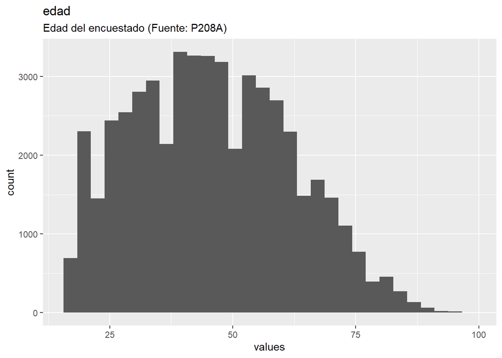

Distribution of values for edad

0 missing values.

#### Summary statistics

| name | label | data_type | n_missing | complete_rate | min | median | max | mean | sd | hist |
| --- | --- | --- | --- | --- | --- | --- | --- | --- | --- | --- |
| edad | Edad del encuestado (Fuente: P208A) | numeric | 0 | 1 | 17 | 45 | 98 | 45.7929 | 16.05015 | ▆▇▇▃▁ |

### sexo

Sexo del encuestado (Fuente: P207)

#### Distribution

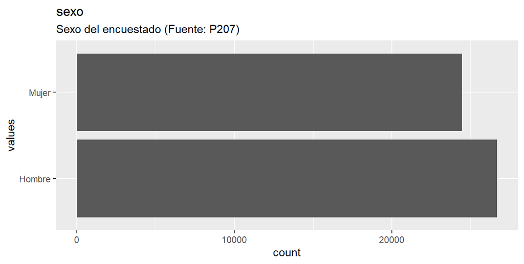

Distribution of values for sexo

0 missing values.

#### Summary statistics

| name | label | data_type | ordered | value_labels | n_missing | complete_rate | n_unique | top_counts |
| --- | --- | --- | --- | --- | --- | --- | --- | --- |
| sexo | Sexo del encuestado (Fuente: P207) | factor | FALSE | 1. Hombre, 2. Mujer | 0 | 1 | 2 | Hom: 26703, Muj: 24461 |

### tiene_ruc_etiqueta

Registro en SUNAT del centro de trabajo (Fuente: P510A1)

#### Distribution

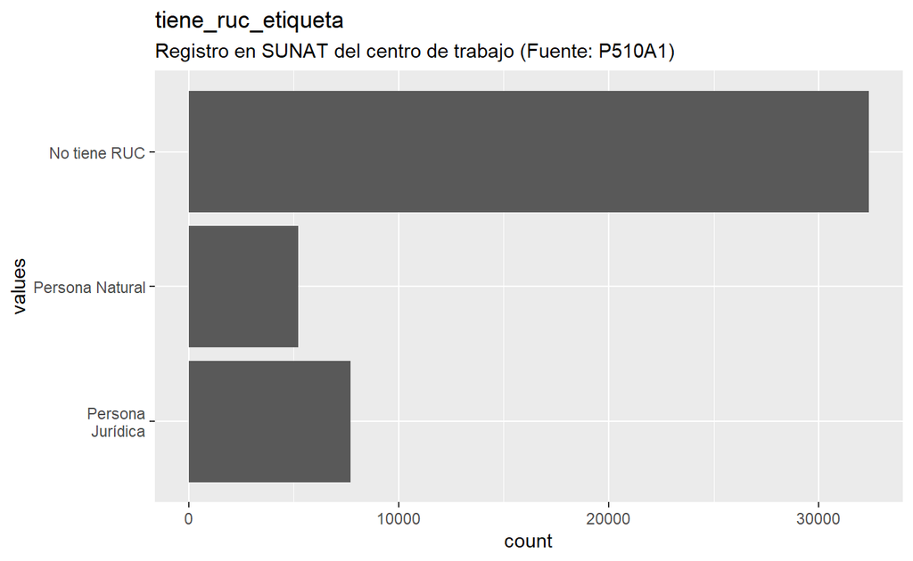

Distribution of values for tiene_ruc_etiqueta

5864 missing values.

#### Summary statistics

| name | label | data_type | ordered | value_labels | n_missing | complete_rate | n_unique | top_counts |
| --- | --- | --- | --- | --- | --- | --- | --- | --- |
| tiene_ruc_etiqueta | Registro en SUNAT del centro de trabajo (Fuente: P510A1) | factor | FALSE | 1. Persona Jurídica, 2. Persona Natural, 3. No tiene RUC | 5864 | 0.8853882 | 3 | No : 32379, Per: 7708, Per: 5213 |

### categoria_ocupacional_etiqueta

Categoría Ocupacional Principal (Fuente: P507)

#### Distribution

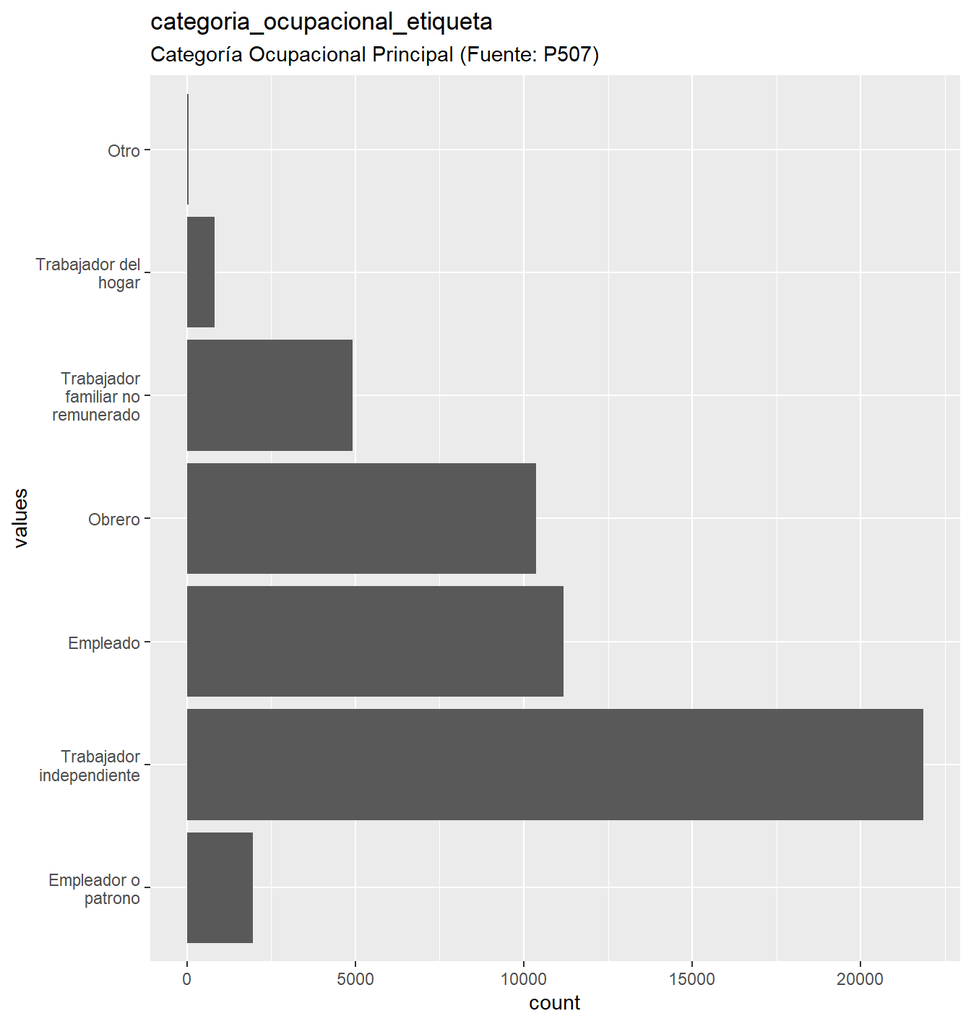

Distribution of values for categoria_ocupacional_etiqueta

0 missing values.

#### Summary statistics

| name | label | data_type | ordered | value_labels | n_missing | complete_rate | n_unique | top_counts |
| --- | --- | --- | --- | --- | --- | --- | --- | --- |
| categoria_ocupacional_etiqueta | Categoría Ocupacional Principal (Fuente: P507) | factor | FALSE | 1. Empleador o patrono, 2. Trabajador independiente, 3. Empleado, 4. Obrero, 5. Trabajador familiar no remunerado, 6. Trabajador del hogar, 7. Otro | 0 | 1 | 7 | Tra: 21857, Emp: 11176, Obr: 10372, Tra: 4924 |

### tipo_contrato_etiqueta

Tipo de Contrato Laboral (Fuente: P511A)

#### Distribution

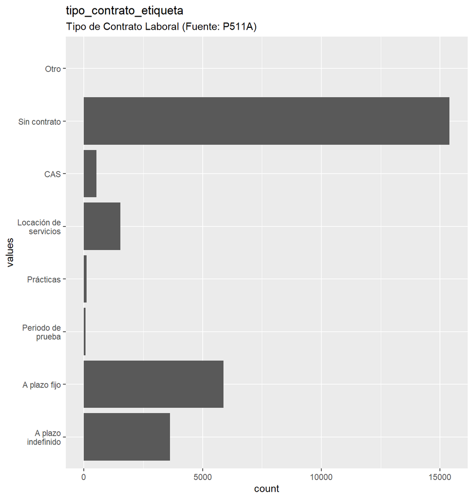

Distribution of values for tipo_contrato_etiqueta

24047 missing values.

#### Summary statistics

| name | label | data_type | ordered | value_labels | n_missing | complete_rate | n_unique | top_counts |
| --- | --- | --- | --- | --- | --- | --- | --- | --- |
| tipo_contrato_etiqueta | Tipo de Contrato Laboral (Fuente: P511A) | factor | FALSE | 1. A plazo indefinido, 2. A plazo fijo, 3. Periodo de prueba, 4. Prácticas, 5. Locación de servicios, 6. CAS, 7. Sin contrato, 8. Otro | 24047 | 0.5300016 | 7 | Sin: 15395, A p: 5885, A p: 3619, Loc: 1529 |

### formalidad_sector

Formalidad del Centro de Empleo

#### Distribution

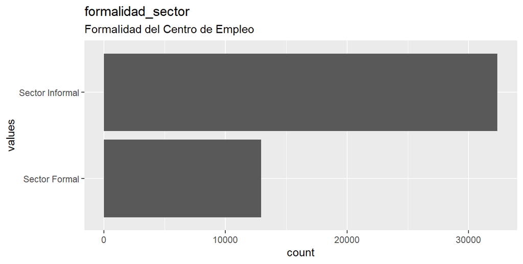

Distribution of values for formalidad_sector

5864 missing values.

#### Summary statistics

| name | label | data_type | ordered | value_labels | n_missing | complete_rate | n_unique | top_counts | description |
| --- | --- | --- | --- | --- | --- | --- | --- | --- | --- |
| formalidad_sector | Formalidad del Centro de Empleo | factor | FALSE | 1. Sector Formal, 2. Sector Informal | 5864 | 0.8853882 | 2 | Sec: 32379, Sec: 12921 | Un centro de empleo es informal si no tiene ningún tipo de registro en la SUNAT según la variable tiene_ruc_etiqueta |

### formalidad_empleo

Formalidad laboral

#### Distribution

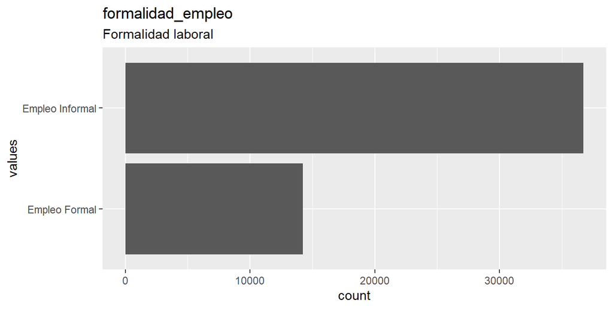

Distribution of values for formalidad_empleo

231 missing values.

#### Summary statistics

[output not shown]

### grupo_edad_teoria

Grupo de Edad (Cortes segúm metodología INEI)

#### Distribution

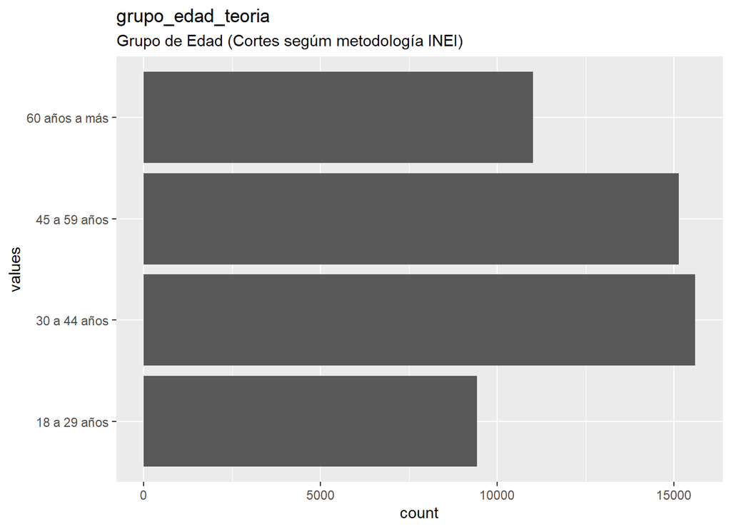

Distribution of values for grupo_edad_teoria

0 missing values.

#### Summary statistics

| name | label | data_type | ordered | value_labels | n_missing | complete_rate | n_unique | top_counts | description |
| --- | --- | --- | --- | --- | --- | --- | --- | --- | --- |
| grupo_edad_teoria | Grupo de Edad (Cortes segúm metodología INEI) | factor | FALSE | 1. 18 a 29 años, 2. 30 a 44 años, 3. 45 a 59 años, 4. 60 años a más | 0 | 1 | 4 | 30 : 15599, 45 : 15128, 60 : 11011, 18 : 9426 | Se utilizan los grupos de edad definidos por el INEI en sus informes de principales resultados de la ENAHO |

### quintil_ingreso

Quintil de Ingresos (a partir de ingreso_prin_imputado)

#### Distribution

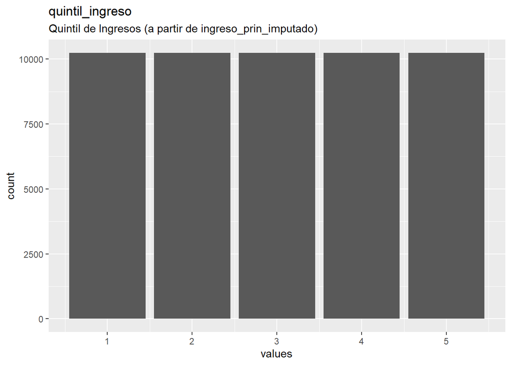

Distribution of values for quintil_ingreso

0 missing values.

#### Summary statistics

| name | label | data_type | n_missing | complete_rate | min | median | max | mean | sd | hist |
| --- | --- | --- | --- | --- | --- | --- | --- | --- | --- | --- |
| quintil_ingreso | Quintil de Ingresos (a partir de ingreso_prin_imputado) | numeric | 0 | 1 | 1 | 3 | 5 | 2.999961 | 1.414214 | ▇▇▇▇▇ |

### afiliacion_salud

Condición de afiliación al sistema de salud

#### Distribution

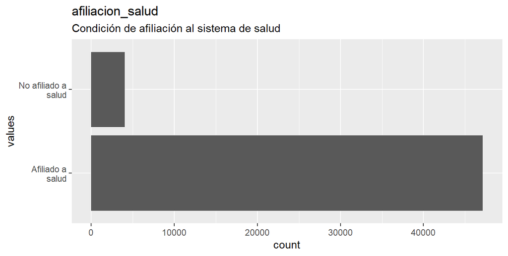

Distribution of values for afiliacion_salud

0 missing values.

#### Summary statistics

| name | label | data_type | ordered | value_labels | n_missing | complete_rate | n_unique | top_counts | description |
| --- | --- | --- | --- | --- | --- | --- | --- | --- | --- |
| afiliacion_salud | Condición de afiliación al sistema de salud | factor | FALSE | 1. Afiliado a salud, 2. No afiliado a salud | 0 | 1 | 2 | Afi: 47129, No : 4035 | Una persona está afiliada a un régimen de salud si respondió ‘1’ en alguna de las preguntas de la P491 a la P4198 de la ENAHO |

### afiliacion_pensiones

Tipo de sistema previsional al cual está afiliado

#### Distribution

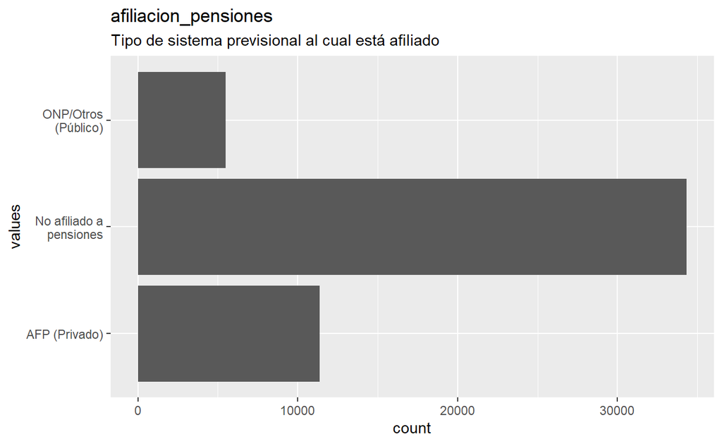

Distribution of values for afiliacion_pensiones

0 missing values.

#### Summary statistics

[output not shown]

### indice_confianza_simple

Índice de Confianza Institucional (Promedio Normalizado 0-1)

#### Distribution

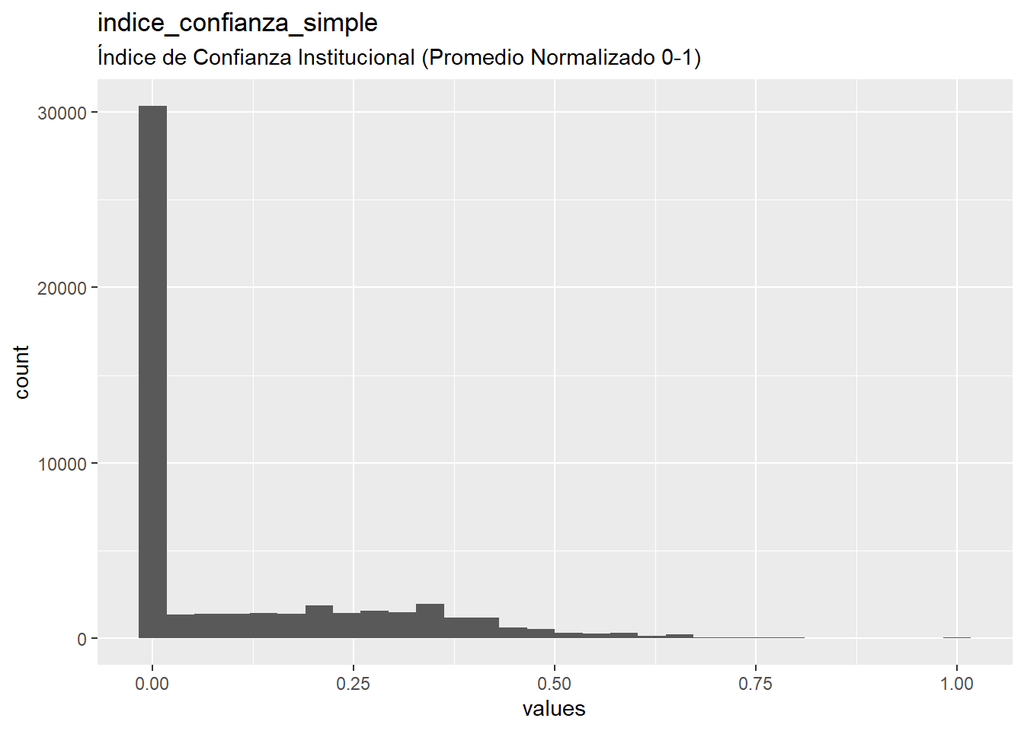

Distribution of values for indice_confianza_simple

190 missing values.

#### Summary statistics

[output not shown]

### ingreso_prin_imputado

Ingreso total mensual proveniente de la -ocupación principal (Soles corrientes) (Fuente: P524A1)

#### Distribution

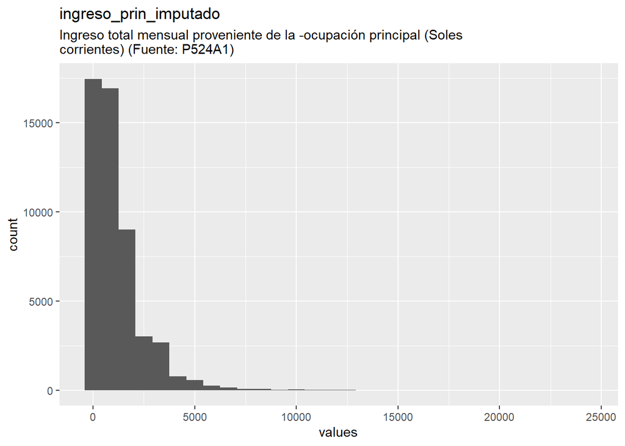

Distribution of values for ingreso_prin_imputado

0 missing values.

#### Summary statistics

| name | label | data_type | n_missing | complete_rate | min | median | max | mean | sd | hist | description |
| --- | --- | --- | --- | --- | --- | --- | --- | --- | --- | --- | --- |
| ingreso_prin_imputado | Ingreso total mensual proveniente de la -ocupación principal (Soles corrientes) (Fuente: P524A1) | numeric | 0 | 1 | 5 | 885 | 24155 | 1186.573 | 1292.822 | ▇▁▁▁▁ | Los valores 999999 se recodificaron a NA. Los casos perdidos (MNAR) fueron imputados usando el algoritmo MICE condicionado al nivel educativo. |

### tipologia_laboral

Profundidad de la Informalidad

#### Distribution

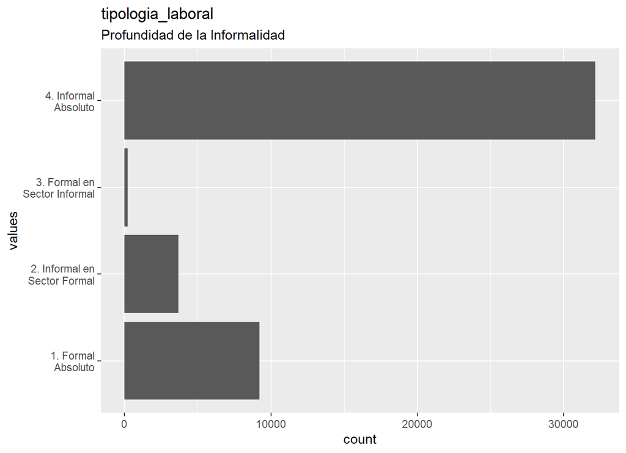

Distribution of values for tipologia_laboral

5864 missing values.

#### Summary statistics

| name | label | data_type | ordered | value_labels | n_missing | complete_rate | n_unique | top_counts | description |
| --- | --- | --- | --- | --- | --- | --- | --- | --- | --- |
| tipologia_laboral | Profundidad de la Informalidad | factor | FALSE | 1. 1. Formal Absoluto, 2. 2. Informal en Sector Formal, 3. 3. Formal en Sector Informal, 4. 4. Informal Absoluto | 5864 | 0.8853882 | 4 | 4. : 32162, 1. : 9229, 2. : 3692, 3. : 217 | Construida a partir del cruce de formalidad_sector (proxy: RUC) y formalidad_empleo (proxy: Categoría ocupacional y tipo de contrato). |

## Missingness report

| description | indice_confianza_simple | formalidad_empleo | tiene_ruc_etiqueta | formalidad_sector | tipologia_laboral | tipo_contrato_etiqueta | var_miss | n_miss |
| --- | --- | --- | --- | --- | --- | --- | --- | --- |
| Missing values per variable | 190 | 231 | 5864 | 5864 | 5864 | 24047 | 42060 | 42060 |
| Missing values in 1 variables | 1 | 1 | 1 | 1 | 1 | 0 | 1 | 23685 |
| Missing values in 0 variables | 1 | 1 | 1 | 1 | 1 | 1 | 0 | 21430 |
| Missing values in 3 variables | 1 | 1 | 0 | 0 | 0 | 1 | 3 | 5629 |
| 5 other, less frequent patterns | 1 | 3 | 2 | 2 | 2 | 2 | 18 | 420 |